# Risk Factor Analysis

## Outcome Variable

**Outcome Variable:** whz

## Predictor Variables

**Intervention Variable:** hfoodsec

**Adjustment Set:**

- arm
- sex
- W_mage
- meducyrs
- feducyrs
- hhwealth_quart
- vagbrth
- W_nrooms
- W_nchldlt5
- brthmon
- W_parity
- impfloor
- impsan
- safeh20
- delta_W_mage
- delta_meducyrs
- delta_feducyrs
- delta_hhwealth_quart
- delta_vagbrth
- delta_W_nrooms
- delta_W_nchldlt5
- delta_brthmon
- delta_W_parity
- delta_impfloor
- delta_impsan
- delta_safeh20

## Stratifying Variables

The analysis was stratified on these variable(s):

- agecat
- studyid
- country

## Data Summary

| agecat | studyid | country | hfoodsec | n_cell | n | outcome_variable |
| --- | --- | --- | --- | --- | --- | --- |
| Birth | GMS-Nepal | NEPAL | Food Secure | 442 | 620 | whz |
| Birth | GMS-Nepal | NEPAL | Mildly Food Insecure | 100 | 620 | whz |
| Birth | GMS-Nepal | NEPAL | Food Insecure | 78 | 620 | whz |
| Birth | JiVitA-3 | BANGLADESH | Food Secure | 5797 | 11763 | whz |
| Birth | JiVitA-3 | BANGLADESH | Mildly Food Insecure | 3947 | 11763 | whz |
| Birth | JiVitA-3 | BANGLADESH | Food Insecure | 2019 | 11763 | whz |
| Birth | JiVitA-4 | BANGLADESH | Food Secure | 1205 | 2383 | whz |
| Birth | JiVitA-4 | BANGLADESH | Mildly Food Insecure | 870 | 2383 | whz |
| Birth | JiVitA-4 | BANGLADESH | Food Insecure | 308 | 2383 | whz |
| Birth | MAL-ED | BANGLADESH | Food Secure | 138 | 162 | whz |
| Birth | MAL-ED | BANGLADESH | Mildly Food Insecure | 3 | 162 | whz |
| Birth | MAL-ED | BANGLADESH | Food Insecure | 21 | 162 | whz |
| Birth | MAL-ED | BRAZIL | Food Secure | 0 | 26 | whz |
| Birth | MAL-ED | BRAZIL | Mildly Food Insecure | 4 | 26 | whz |
| Birth | MAL-ED | BRAZIL | Food Insecure | 22 | 26 | whz |
| Birth | MAL-ED | INDIA | Food Secure | 32 | 35 | whz |
| Birth | MAL-ED | INDIA | Mildly Food Insecure | 1 | 35 | whz |
| Birth | MAL-ED | INDIA | Food Insecure | 2 | 35 | whz |
| Birth | MAL-ED | NEPAL | Food Secure | 10 | 14 | whz |
| Birth | MAL-ED | NEPAL | Mildly Food Insecure | 1 | 14 | whz |
| Birth | MAL-ED | NEPAL | Food Insecure | 3 | 14 | whz |
| Birth | MAL-ED | PERU | Food Secure | 23 | 89 | whz |
| Birth | MAL-ED | PERU | Mildly Food Insecure | 22 | 89 | whz |
| Birth | MAL-ED | PERU | Food Insecure | 44 | 89 | whz |
| Birth | MAL-ED | SOUTH AFRICA | Food Secure | 45 | 87 | whz |
| Birth | MAL-ED | SOUTH AFRICA | Mildly Food Insecure | 9 | 87 | whz |
| Birth | MAL-ED | SOUTH AFRICA | Food Insecure | 33 | 87 | whz |
| Birth | NIH-Birth | BANGLADESH | Food Secure | 86 | 575 | whz |
| Birth | NIH-Birth | BANGLADESH | Mildly Food Insecure | 453 | 575 | whz |
| Birth | NIH-Birth | BANGLADESH | Food Insecure | 36 | 575 | whz |

[output cut: 69 more lines]

The following strata were considered:

- agecat: 24 months, studyid: GMS-Nepal, country: NEPAL
- agecat: 24 months, studyid: JiVitA-3, country: BANGLADESH
- agecat: 24 months, studyid: JiVitA-4, country: BANGLADESH
- agecat: 24 months, studyid: MAL-ED, country: BANGLADESH
- agecat: 24 months, studyid: MAL-ED, country: BRAZIL
- agecat: 24 months, studyid: MAL-ED, country: INDIA
- agecat: 24 months, studyid: MAL-ED, country: NEPAL
- agecat: 24 months, studyid: MAL-ED, country: PERU
- agecat: 24 months, studyid: MAL-ED, country: SOUTH AFRICA
- agecat: 24 months, studyid: NIH-Birth, country: BANGLADESH
- agecat: 24 months, studyid: NIH-Crypto, country: BANGLADESH
- agecat: 6 months, studyid: GMS-Nepal, country: NEPAL
- agecat: 6 months, studyid: JiVitA-3, country: BANGLADESH
- agecat: 6 months, studyid: JiVitA-4, country: BANGLADESH
- agecat: 6 months, studyid: MAL-ED, country: BANGLADESH
- agecat: 6 months, studyid: MAL-ED, country: BRAZIL
- agecat: 6 months, studyid: MAL-ED, country: INDIA
- agecat: 6 months, studyid: MAL-ED, country: NEPAL
- agecat: 6 months, studyid: MAL-ED, country: PERU
- agecat: 6 months, studyid: MAL-ED, country: SOUTH AFRICA
- agecat: 6 months, studyid: NIH-Birth, country: BANGLADESH
- agecat: 6 months, studyid: NIH-Crypto, country: BANGLADESH
- agecat: Birth, studyid: GMS-Nepal, country: NEPAL
- agecat: Birth, studyid: JiVitA-3, country: BANGLADESH
- agecat: Birth, studyid: JiVitA-4, country: BANGLADESH
- agecat: Birth, studyid: MAL-ED, country: BANGLADESH
- agecat: Birth, studyid: MAL-ED, country: BRAZIL
- agecat: Birth, studyid: MAL-ED, country: INDIA
- agecat: Birth, studyid: MAL-ED, country: NEPAL
- agecat: Birth, studyid: MAL-ED, country: PERU
- agecat: Birth, studyid: MAL-ED, country: SOUTH AFRICA
- agecat: Birth, studyid: NIH-Birth, country: BANGLADESH
- agecat: Birth, studyid: NIH-Crypto, country: BANGLADESH

### Dropped Strata

Some strata were dropped due to rare outcomes:

- agecat: Birth, studyid: MAL-ED, country: BANGLADESH
- agecat: Birth, studyid: MAL-ED, country: BRAZIL
- agecat: Birth, studyid: MAL-ED, country: INDIA
- agecat: Birth, studyid: MAL-ED, country: NEPAL
- agecat: 6 months, studyid: MAL-ED, country: BANGLADESH
- agecat: 6 months, studyid: MAL-ED, country: BRAZIL
- agecat: 24 months, studyid: MAL-ED, country: BANGLADESH
- agecat: 24 months, studyid: MAL-ED, country: BRAZIL

## Methods Detail

We’re interested in the causal parameters $E[Y_a]$ for all values of $a \in \mathcal{A}$. These parameters represent the mean outcome if, possibly contrary to fact, we intervened to set all units to have $A=a$. Under the randomization and positivity assumptions, these are identified by the statistical parameters $\psi_a=E_W[E_{Y|A,W}(Y|A=a,W)]$. In addition, we’re interested in the mean of $Y$, $E[Y]$ under no intervention (the observed mean). We will estimate these parameters by using SuperLearner to fit the relevant likelihood factors – $E_{Y|A,W}(Y|A=a,W)$ and $p(A=a|W)$, and then updating our likelihood fit using a joint TMLE.

For unadjusted analyses ($W=\{\}$), initial likelihoods were estimated using Lrnr_glm to estimate the simple $E(Y|A)$ and Lrnr_mean to estimate $p(A)$. For adjusted analyses, a small library containing Lrnr_glmnet, Lrnr_xgboost, and Lrnr_mean was used.

Having estimated these parameters, we will then use the delta method to estimate relative risks and attributable risks relative to a prespecified baseline level of $A$.

# Results Detail

## Results Plots

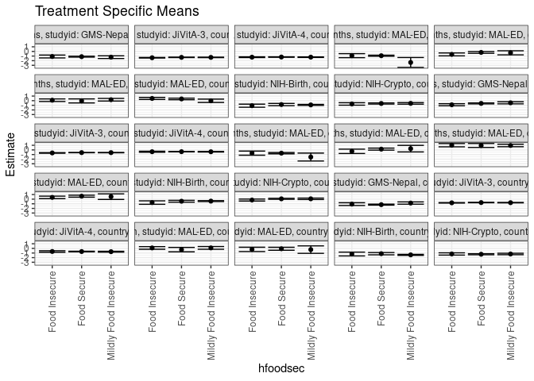

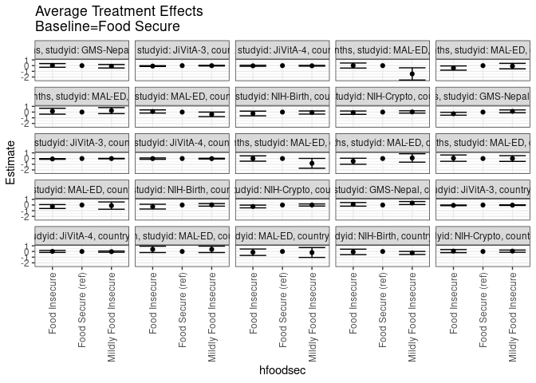

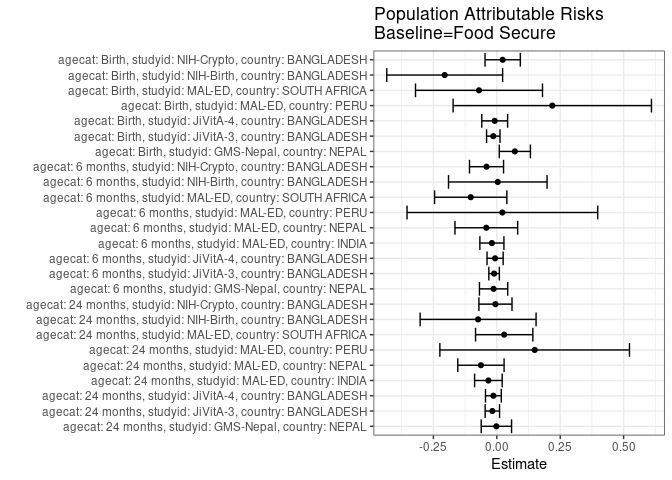

## Results Table

### Parameter: TSM

| agecat | studyid | country | intervention_level | baseline_level | estimate | ci_lower | ci_upper |
| --- | --- | --- | --- | --- | --- | --- | --- |
| Birth | GMS-Nepal | NEPAL | Food Secure | NA | -1.1875833 | -1.2924501 | -1.0827165 |
| Birth | GMS-Nepal | NEPAL | Mildly Food Insecure | NA | -0.8444844 | -1.0909997 | -0.5979692 |
| Birth | GMS-Nepal | NEPAL | Food Insecure | NA | -1.0727070 | -1.3729197 | -0.7724943 |
| Birth | JiVitA-3 | BANGLADESH | Food Secure | NA | -0.7369859 | -0.7720123 | -0.7019596 |
| Birth | JiVitA-3 | BANGLADESH | Mildly Food Insecure | NA | -0.7609311 | -0.8025221 | -0.7193401 |
| Birth | JiVitA-3 | BANGLADESH | Food Insecure | NA | -0.7930855 | -0.8459598 | -0.7402112 |
| Birth | JiVitA-4 | BANGLADESH | Food Secure | NA | -0.6814641 | -0.7484609 | -0.6144673 |
| Birth | JiVitA-4 | BANGLADESH | Mildly Food Insecure | NA | -0.7112382 | -0.7997503 | -0.6227262 |
| Birth | JiVitA-4 | BANGLADESH | Food Insecure | NA | -0.6669839 | -0.8344549 | -0.4995128 |
| Birth | MAL-ED | PERU | Food Secure | NA | -0.2670291 | -0.7447178 | 0.2106595 |
| Birth | MAL-ED | PERU | Mildly Food Insecure | NA | 0.1076436 | -0.1915061 | 0.4067932 |
| Birth | MAL-ED | PERU | Food Insecure | NA | 0.1024201 | -0.1822820 | 0.3871222 |
| Birth | MAL-ED | SOUTH AFRICA | Food Secure | NA | -0.0800000 | -0.4003913 | 0.2403913 |
| Birth | MAL-ED | SOUTH AFRICA | Mildly Food Insecure | NA | -0.2611111 | -1.0678216 | 0.5455994 |
| Birth | MAL-ED | SOUTH AFRICA | Food Insecure | NA | -0.2157576 | -0.6840291 | 0.2525139 |
| Birth | NIH-Birth | BANGLADESH | Food Secure | NA | -1.1444205 | -1.3885519 | -0.9002891 |
| Birth | NIH-Birth | BANGLADESH | Mildly Food Insecure | NA | -1.4020739 | -1.5103166 | -1.2938312 |
| Birth | NIH-Birth | BANGLADESH | Food Insecure | NA | -1.2195962 | -1.6310816 | -0.8081109 |
| Birth | NIH-Crypto | BANGLADESH | Food Secure | NA | -1.2672864 | -1.3786278 | -1.1559450 |
| Birth | NIH-Crypto | BANGLADESH | Mildly Food Insecure | NA | -1.2094962 | -1.3708175 | -1.0481749 |
| Birth | NIH-Crypto | BANGLADESH | Food Insecure | NA | -1.2021874 | -1.4459614 | -0.9584135 |
| 6 months | GMS-Nepal | NEPAL | Food Secure | NA | -0.5891295 | -0.6956492 | -0.4826097 |
| 6 months | GMS-Nepal | NEPAL | Mildly Food Insecure | NA | -0.4603373 | -0.6874382 | -0.2332365 |
| 6 months | GMS-Nepal | NEPAL | Food Insecure | NA | -0.8842560 | -1.1125482 | -0.6559638 |
| 6 months | JiVitA-3 | BANGLADESH | Food Secure | NA | -0.5825236 | -0.6114627 | -0.5535846 |
| 6 months | JiVitA-3 | BANGLADESH | Mildly Food Insecure | NA | -0.5886881 | -0.6232589 | -0.5541174 |
| 6 months | JiVitA-3 | BANGLADESH | Food Insecure | NA | -0.6533766 | -0.7109021 | -0.5958511 |
| 6 months | JiVitA-4 | BANGLADESH | Food Secure | NA | -0.3827431 | -0.4307800 | -0.3347062 |
| 6 months | JiVitA-4 | BANGLADESH | Mildly Food Insecure | NA | -0.3991097 | -0.4567950 | -0.3414244 |
| 6 months | JiVitA-4 | BANGLADESH | Food Insecure | NA | -0.3916717 | -0.5043328 | -0.2790106 |
| 6 months | MAL-ED | INDIA | Food Secure | NA | -0.7025789 | -0.8453715 | -0.5597864 |
| 6 months | MAL-ED | INDIA | Mildly Food Insecure | NA | -1.5420000 | -2.3989104 | -0.6850896 |
| 6 months | MAL-ED | INDIA | Food Insecure | NA | -0.6978922 | -1.1435259 | -0.2522584 |
| 6 months | MAL-ED | NEPAL | Food Secure | NA | 0.1692251 | -0.0517248 | 0.3901751 |
| 6 months | MAL-ED | NEPAL | Mildly Food Insecure | NA | 0.2751376 | -0.4342108 | 0.9844860 |
| 6 months | MAL-ED | NEPAL | Food Insecure | NA | -0.3039563 | -0.7719835 | 0.1640710 |
| 6 months | MAL-ED | PERU | Food Secure | NA | 0.9600368 | 0.5304507 | 1.3896229 |
| 6 months | MAL-ED | PERU | Mildly Food Insecure | NA | 0.9638435 | 0.6966087 | 1.2310782 |
| 6 months | MAL-ED | PERU | Food Insecure | NA | 1.0274688 | 0.6722773 | 1.3826603 |
| 6 months | MAL-ED | SOUTH AFRICA | Food Secure | NA | 0.6458273 | 0.4306975 | 0.8609571 |
| 6 months | MAL-ED | SOUTH AFRICA | Mildly Food Insecure | NA | 0.5415524 | -0.0619292 | 1.1450340 |
| 6 months | MAL-ED | SOUTH AFRICA | Food Insecure | NA | 0.3794181 | 0.1082613 | 0.6505748 |
| 6 months | NIH-Birth | BANGLADESH | Food Secure | NA | -0.4512121 | -0.6516542 | -0.2507699 |
| 6 months | NIH-Birth | BANGLADESH | Mildly Food Insecure | NA | -0.4250254 | -0.5298581 | -0.3201927 |
| 6 months | NIH-Birth | BANGLADESH | Food Insecure | NA | -0.7378972 | -1.1085372 | -0.3672572 |
| 6 months | NIH-Crypto | BANGLADESH | Food Secure | NA | 0.0703450 | -0.0356540 | 0.1763440 |
| 6 months | NIH-Crypto | BANGLADESH | Mildly Food Insecure | NA | 0.0743394 | -0.0792600 | 0.2279389 |
| 6 months | NIH-Crypto | BANGLADESH | Food Insecure | NA | -0.1904429 | -0.4058333 | 0.0249474 |
| 24 months | GMS-Nepal | NEPAL | Food Secure | NA | -1.1287873 | -1.2305632 | -1.0270115 |
| 24 months | GMS-Nepal | NEPAL | Mildly Food Insecure | NA | -1.2360472 | -1.5282356 | -0.9438588 |
| 24 months | GMS-Nepal | NEPAL | Food Insecure | NA | -1.0929650 | -1.4002312 | -0.7856988 |
| 24 months | JiVitA-3 | BANGLADESH | Food Secure | NA | -1.2812456 | -1.3175996 | -1.2448916 |
| 24 months | JiVitA-3 | BANGLADESH | Mildly Food Insecure | NA | -1.2858565 | -1.3315998 | -1.2401132 |
| 24 months | JiVitA-3 | BANGLADESH | Food Insecure | NA | -1.3629993 | -1.4217446 | -1.3042540 |
| 24 months | JiVitA-4 | BANGLADESH | Food Secure | NA | -1.2108341 | -1.2553099 | -1.1663583 |
| 24 months | JiVitA-4 | BANGLADESH | Mildly Food Insecure | NA | -1.2363539 | -1.2917709 | -1.1809369 |
| 24 months | JiVitA-4 | BANGLADESH | Food Insecure | NA | -1.2413128 | -1.3206788 | -1.1619468 |
| 24 months | MAL-ED | INDIA | Food Secure | NA | -0.9256316 | -1.0440690 | -0.8071941 |
| 24 months | MAL-ED | INDIA | Mildly Food Insecure | NA | -2.3840000 | -3.4554070 | -1.3125930 |
| 24 months | MAL-ED | INDIA | Food Insecure | NA | -0.9111765 | -1.3418053 | -0.4805476 |
| 24 months | MAL-ED | NEPAL | Food Secure | NA | -0.2104492 | -0.4037692 | -0.0171292 |
| 24 months | MAL-ED | NEPAL | Mildly Food Insecure | NA | -0.2942561 | -0.7346826 | 0.1461703 |
| 24 months | MAL-ED | NEPAL | Food Insecure | NA | -0.6391593 | -0.9521996 | -0.3261189 |
| 24 months | MAL-ED | PERU | Food Secure | NA | -0.0510439 | -0.4876534 | 0.3855655 |
| 24 months | MAL-ED | PERU | Mildly Food Insecure | NA | 0.2099514 | -0.0768194 | 0.4967222 |
| 24 months | MAL-ED | PERU | Food Insecure | NA | 0.1038965 | -0.1673853 | 0.3751783 |
| 24 months | MAL-ED | SOUTH AFRICA | Food Secure | NA | 0.3788969 | 0.2105226 | 0.5472712 |
| 24 months | MAL-ED | SOUTH AFRICA | Mildly Food Insecure | NA | -0.0227188 | -0.3821613 | 0.3367237 |
| 24 months | MAL-ED | SOUTH AFRICA | Food Insecure | NA | 0.4846277 | 0.2664857 | 0.7027697 |
| 24 months | NIH-Birth | BANGLADESH | Food Secure | NA | -0.8377757 | -1.0831276 | -0.5924237 |
| 24 months | NIH-Birth | BANGLADESH | Mildly Food Insecure | NA | -0.9144572 | -1.0306989 | -0.7982155 |
| 24 months | NIH-Birth | BANGLADESH | Food Insecure | NA | -1.0860769 | -1.4217840 | -0.7503699 |
| 24 months | NIH-Crypto | BANGLADESH | Food Secure | NA | -0.6049752 | -0.7277557 | -0.4821946 |
| 24 months | NIH-Crypto | BANGLADESH | Mildly Food Insecure | NA | -0.5814279 | -0.7519292 | -0.4109267 |
| 24 months | NIH-Crypto | BANGLADESH | Food Insecure | NA | -0.7069115 | -0.9719542 | -0.4418688 |

### Parameter: E(Y)

| agecat | studyid | country | intervention_level | baseline_level | estimate | ci_lower | ci_upper |
| --- | --- | --- | --- | --- | --- | --- | --- |
| Birth | GMS-Nepal | NEPAL | NA | NA | -1.1165161 | -1.2055683 | -1.0274639 |
| Birth | JiVitA-3 | BANGLADESH | NA | NA | -0.7508875 | -0.7730765 | -0.7286985 |
| Birth | JiVitA-4 | BANGLADESH | NA | NA | -0.6898154 | -0.7422632 | -0.6373675 |
| Birth | MAL-ED | PERU | NA | NA | -0.0483146 | -0.2475806 | 0.1509514 |
| Birth | MAL-ED | SOUTH AFRICA | NA | NA | -0.1502299 | -0.4075620 | 0.1071022 |
| Birth | NIH-Birth | BANGLADESH | NA | NA | -1.3499217 | -1.4444634 | -1.2553801 |
| Birth | NIH-Crypto | BANGLADESH | NA | NA | -1.2441513 | -1.3281130 | -1.1601897 |
| 6 months | GMS-Nepal | NEPAL | NA | NA | -0.6018803 | -0.6892284 | -0.5145323 |
| 6 months | JiVitA-3 | BANGLADESH | NA | NA | -0.5932301 | -0.6127836 | -0.5736767 |
| 6 months | JiVitA-4 | BANGLADESH | NA | NA | -0.3895527 | -0.4270314 | -0.3520739 |
| 6 months | MAL-ED | INDIA | NA | NA | -0.7220008 | -0.8576809 | -0.5863207 |
| 6 months | MAL-ED | NEPAL | NA | NA | 0.1277734 | -0.0649431 | 0.3204900 |
| 6 months | MAL-ED | PERU | NA | NA | 0.9819369 | 0.7674415 | 1.1964324 |
| 6 months | MAL-ED | SOUTH AFRICA | NA | NA | 0.5429020 | 0.3813518 | 0.7044523 |
| 6 months | NIH-Birth | BANGLADESH | NA | NA | -0.4474038 | -0.5378167 | -0.3569909 |
| 6 months | NIH-Crypto | BANGLADESH | NA | NA | 0.0297622 | -0.0491685 | 0.1086930 |
| 24 months | GMS-Nepal | NEPAL | NA | NA | -1.1304997 | -1.2205265 | -1.0404728 |
| 24 months | JiVitA-3 | BANGLADESH | NA | NA | -1.2988352 | -1.3224626 | -1.2752078 |
| 24 months | JiVitA-4 | BANGLADESH | NA | NA | -1.2243590 | -1.2566569 | -1.1920612 |
| 24 months | MAL-ED | INDIA | NA | NA | -0.9588679 | -1.0774868 | -0.8402491 |
| 24 months | MAL-ED | NEPAL | NA | NA | -0.2730469 | -0.4358169 | -0.1102769 |
| 24 months | MAL-ED | PERU | NA | NA | 0.0982009 | -0.0794754 | 0.2758773 |
| 24 months | MAL-ED | SOUTH AFRICA | NA | NA | 0.4080227 | 0.2828348 | 0.5332106 |
| 24 months | NIH-Birth | BANGLADESH | NA | NA | -0.9115790 | -1.0095022 | -0.8136559 |
| 24 months | NIH-Crypto | BANGLADESH | NA | NA | -0.6103502 | -0.7050157 | -0.5156847 |

### Parameter: ATE

| agecat | studyid | country | intervention_level | baseline_level | estimate | ci_lower | ci_upper |
| --- | --- | --- | --- | --- | --- | --- | --- |
| Birth | GMS-Nepal | NEPAL | Food Secure | Food Secure | 0.0000000 | 0.0000000 | 0.0000000 |
| Birth | GMS-Nepal | NEPAL | Mildly Food Insecure | Food Secure | 0.3430989 | 0.0755059 | 0.6106919 |
| Birth | GMS-Nepal | NEPAL | Food Insecure | Food Secure | 0.1148763 | -0.2020191 | 0.4317717 |
| Birth | JiVitA-3 | BANGLADESH | Food Secure | Food Secure | 0.0000000 | 0.0000000 | 0.0000000 |
| Birth | JiVitA-3 | BANGLADESH | Mildly Food Insecure | Food Secure | -0.0239452 | -0.0765060 | 0.0286157 |
| Birth | JiVitA-3 | BANGLADESH | Food Insecure | Food Secure | -0.0560996 | -0.1179213 | 0.0057221 |
| Birth | JiVitA-4 | BANGLADESH | Food Secure | Food Secure | 0.0000000 | 0.0000000 | 0.0000000 |
| Birth | JiVitA-4 | BANGLADESH | Mildly Food Insecure | Food Secure | -0.0297741 | -0.1396189 | 0.0800707 |
| Birth | JiVitA-4 | BANGLADESH | Food Insecure | Food Secure | 0.0144803 | -0.1653844 | 0.1943449 |
| Birth | MAL-ED | PERU | Food Secure | Food Secure | 0.0000000 | 0.0000000 | 0.0000000 |
| Birth | MAL-ED | PERU | Mildly Food Insecure | Food Secure | 0.3746727 | -0.1891907 | 0.9385361 |
| Birth | MAL-ED | PERU | Food Insecure | Food Secure | 0.3694493 | -0.1882075 | 0.9271060 |
| Birth | MAL-ED | SOUTH AFRICA | Food Secure | Food Secure | 0.0000000 | 0.0000000 | 0.0000000 |
| Birth | MAL-ED | SOUTH AFRICA | Mildly Food Insecure | Food Secure | -0.1811111 | -1.0491159 | 0.6868937 |
| Birth | MAL-ED | SOUTH AFRICA | Food Insecure | Food Secure | -0.1357576 | -0.7031452 | 0.4316301 |
| Birth | NIH-Birth | BANGLADESH | Food Secure | Food Secure | 0.0000000 | 0.0000000 | 0.0000000 |
| Birth | NIH-Birth | BANGLADESH | Mildly Food Insecure | Food Secure | -0.2576534 | -0.5248268 | 0.0095200 |
| Birth | NIH-Birth | BANGLADESH | Food Insecure | Food Secure | -0.0751757 | -0.5537611 | 0.4034096 |
| Birth | NIH-Crypto | BANGLADESH | Food Secure | Food Secure | 0.0000000 | 0.0000000 | 0.0000000 |
| Birth | NIH-Crypto | BANGLADESH | Mildly Food Insecure | Food Secure | 0.0577902 | -0.1384604 | 0.2540407 |
| Birth | NIH-Crypto | BANGLADESH | Food Insecure | Food Secure | 0.0650990 | -0.2034237 | 0.3336217 |
| 6 months | GMS-Nepal | NEPAL | Food Secure | Food Secure | 0.0000000 | 0.0000000 | 0.0000000 |
| 6 months | GMS-Nepal | NEPAL | Mildly Food Insecure | Food Secure | 0.1287921 | -0.1232791 | 0.3808634 |
| 6 months | GMS-Nepal | NEPAL | Food Insecure | Food Secure | -0.2951265 | -0.5466034 | -0.0436497 |
| 6 months | JiVitA-3 | BANGLADESH | Food Secure | Food Secure | 0.0000000 | 0.0000000 | 0.0000000 |
| 6 months | JiVitA-3 | BANGLADESH | Mildly Food Insecure | Food Secure | -0.0061645 | -0.0497116 | 0.0373826 |
| 6 months | JiVitA-3 | BANGLADESH | Food Insecure | Food Secure | -0.0708530 | -0.1337435 | -0.0079625 |
| 6 months | JiVitA-4 | BANGLADESH | Food Secure | Food Secure | 0.0000000 | 0.0000000 | 0.0000000 |
| 6 months | JiVitA-4 | BANGLADESH | Mildly Food Insecure | Food Secure | -0.0163666 | -0.0868143 | 0.0540810 |
| 6 months | JiVitA-4 | BANGLADESH | Food Insecure | Food Secure | -0.0089286 | -0.1279523 | 0.1100950 |
| 6 months | MAL-ED | INDIA | Food Secure | Food Secure | 0.0000000 | 0.0000000 | 0.0000000 |
| 6 months | MAL-ED | INDIA | Mildly Food Insecure | Food Secure | -0.8394211 | -1.7081472 | 0.0293051 |
| 6 months | MAL-ED | INDIA | Food Insecure | Food Secure | 0.0046868 | -0.4632653 | 0.4726389 |
| 6 months | MAL-ED | NEPAL | Food Secure | Food Secure | 0.0000000 | 0.0000000 | 0.0000000 |
| 6 months | MAL-ED | NEPAL | Mildly Food Insecure | Food Secure | 0.1059125 | -0.6358899 | 0.8477149 |
| 6 months | MAL-ED | NEPAL | Food Insecure | Food Secure | -0.4731814 | -1.0018570 | 0.0554942 |
| 6 months | MAL-ED | PERU | Food Secure | Food Secure | 0.0000000 | 0.0000000 | 0.0000000 |
| 6 months | MAL-ED | PERU | Mildly Food Insecure | Food Secure | 0.0038066 | -0.5002074 | 0.5078207 |
| 6 months | MAL-ED | PERU | Food Insecure | Food Secure | 0.0674319 | -0.4888045 | 0.6236684 |
| 6 months | MAL-ED | SOUTH AFRICA | Food Secure | Food Secure | 0.0000000 | 0.0000000 | 0.0000000 |
| 6 months | MAL-ED | SOUTH AFRICA | Mildly Food Insecure | Food Secure | -0.1042749 | -0.7448916 | 0.5363419 |
| 6 months | MAL-ED | SOUTH AFRICA | Food Insecure | Food Secure | -0.2664092 | -0.6128331 | 0.0800147 |
| 6 months | NIH-Birth | BANGLADESH | Food Secure | Food Secure | 0.0000000 | 0.0000000 | 0.0000000 |
| 6 months | NIH-Birth | BANGLADESH | Mildly Food Insecure | Food Secure | 0.0261867 | -0.2001332 | 0.2525066 |
| 6 months | NIH-Birth | BANGLADESH | Food Insecure | Food Secure | -0.2866851 | -0.7093799 | 0.1360097 |
| 6 months | NIH-Crypto | BANGLADESH | Food Secure | Food Secure | 0.0000000 | 0.0000000 | 0.0000000 |
| 6 months | NIH-Crypto | BANGLADESH | Mildly Food Insecure | Food Secure | 0.0039944 | -0.1842230 | 0.1922118 |
| 6 months | NIH-Crypto | BANGLADESH | Food Insecure | Food Secure | -0.2607879 | -0.5029615 | -0.0186143 |
| 24 months | GMS-Nepal | NEPAL | Food Secure | Food Secure | 0.0000000 | 0.0000000 | 0.0000000 |
| 24 months | GMS-Nepal | NEPAL | Mildly Food Insecure | Food Secure | -0.1072599 | -0.4171630 | 0.2026432 |
| 24 months | GMS-Nepal | NEPAL | Food Insecure | Food Secure | 0.0358223 | -0.2876179 | 0.3592626 |
| 24 months | JiVitA-3 | BANGLADESH | Food Secure | Food Secure | 0.0000000 | 0.0000000 | 0.0000000 |
| 24 months | JiVitA-3 | BANGLADESH | Mildly Food Insecure | Food Secure | -0.0046109 | -0.0622209 | 0.0529991 |
| 24 months | JiVitA-3 | BANGLADESH | Food Insecure | Food Secure | -0.0817537 | -0.1489716 | -0.0145358 |
| 24 months | JiVitA-4 | BANGLADESH | Food Secure | Food Secure | 0.0000000 | 0.0000000 | 0.0000000 |
| 24 months | JiVitA-4 | BANGLADESH | Mildly Food Insecure | Food Secure | -0.0255198 | -0.0958226 | 0.0447829 |
| 24 months | JiVitA-4 | BANGLADESH | Food Insecure | Food Secure | -0.0304787 | -0.1214245 | 0.0604671 |
| 24 months | MAL-ED | INDIA | Food Secure | Food Secure | 0.0000000 | 0.0000000 | 0.0000000 |
| 24 months | MAL-ED | INDIA | Mildly Food Insecure | Food Secure | -1.4583684 | -2.5363018 | -0.3804350 |
| 24 months | MAL-ED | INDIA | Food Insecure | Food Secure | 0.0144551 | -0.4321640 | 0.4610742 |
| 24 months | MAL-ED | NEPAL | Food Secure | Food Secure | 0.0000000 | 0.0000000 | 0.0000000 |
| 24 months | MAL-ED | NEPAL | Mildly Food Insecure | Food Secure | -0.0838069 | -0.5650700 | 0.3974562 |
| 24 months | MAL-ED | NEPAL | Food Insecure | Food Secure | -0.4287101 | -0.7987840 | -0.0586361 |
| 24 months | MAL-ED | PERU | Food Secure | Food Secure | 0.0000000 | 0.0000000 | 0.0000000 |
| 24 months | MAL-ED | PERU | Mildly Food Insecure | Food Secure | 0.2609953 | -0.2661677 | 0.7881584 |
| 24 months | MAL-ED | PERU | Food Insecure | Food Secure | 0.1549404 | -0.3638190 | 0.6736998 |
| 24 months | MAL-ED | SOUTH AFRICA | Food Secure | Food Secure | 0.0000000 | 0.0000000 | 0.0000000 |
| 24 months | MAL-ED | SOUTH AFRICA | Mildly Food Insecure | Food Secure | -0.4016157 | -0.8019941 | -0.0012373 |
| 24 months | MAL-ED | SOUTH AFRICA | Food Insecure | Food Secure | 0.1057308 | -0.1710835 | 0.3825451 |
| 24 months | NIH-Birth | BANGLADESH | Food Secure | Food Secure | 0.0000000 | 0.0000000 | 0.0000000 |
| 24 months | NIH-Birth | BANGLADESH | Mildly Food Insecure | Food Secure | -0.0766816 | -0.3483377 | 0.1949745 |
| 24 months | NIH-Birth | BANGLADESH | Food Insecure | Food Secure | -0.2483013 | -0.6641585 | 0.1675560 |
| 24 months | NIH-Crypto | BANGLADESH | Food Secure | Food Secure | 0.0000000 | 0.0000000 | 0.0000000 |
| 24 months | NIH-Crypto | BANGLADESH | Mildly Food Insecure | Food Secure | 0.0235472 | -0.1849447 | 0.2320392 |
| 24 months | NIH-Crypto | BANGLADESH | Food Insecure | Food Secure | -0.1019363 | -0.3939029 | 0.1900303 |

### Parameter: PAR

| agecat | studyid | country | intervention_level | baseline_level | estimate | ci_lower | ci_upper |
| --- | --- | --- | --- | --- | --- | --- | --- |
| Birth | GMS-Nepal | NEPAL | Food Secure | NA | 0.0710672 | 0.0096630 | 0.1324713 |
| Birth | JiVitA-3 | BANGLADESH | Food Secure | NA | -0.0139016 | -0.0403911 | 0.0125879 |
| Birth | JiVitA-4 | BANGLADESH | Food Secure | NA | -0.0083512 | -0.0592674 | 0.0425650 |
| Birth | MAL-ED | PERU | Food Secure | NA | 0.2187145 | -0.1723258 | 0.6097548 |
| Birth | MAL-ED | SOUTH AFRICA | Food Secure | NA | -0.0702299 | -0.3205899 | 0.1801302 |
| Birth | NIH-Birth | BANGLADESH | Food Secure | NA | -0.2055012 | -0.4339114 | 0.0229089 |
| Birth | NIH-Crypto | BANGLADESH | Food Secure | NA | 0.0231350 | -0.0464167 | 0.0926868 |
| 6 months | GMS-Nepal | NEPAL | Food Secure | NA | -0.0127509 | -0.0684223 | 0.0429205 |
| 6 months | JiVitA-3 | BANGLADESH | Food Secure | NA | -0.0107065 | -0.0314920 | 0.0100790 |
| 6 months | JiVitA-4 | BANGLADESH | Food Secure | NA | -0.0068096 | -0.0386011 | 0.0249820 |
| 6 months | MAL-ED | INDIA | Food Secure | NA | -0.0194218 | -0.0668687 | 0.0280250 |
| 6 months | MAL-ED | NEPAL | Food Secure | NA | -0.0414517 | -0.1650401 | 0.0821368 |
| 6 months | MAL-ED | PERU | Food Secure | NA | 0.0219001 | -0.3539793 | 0.3977795 |
| 6 months | MAL-ED | SOUTH AFRICA | Food Secure | NA | -0.1029252 | -0.2454502 | 0.0395997 |
| 6 months | NIH-Birth | BANGLADESH | Food Secure | NA | 0.0038083 | -0.1904772 | 0.1980938 |
| 6 months | NIH-Crypto | BANGLADESH | Food Secure | NA | -0.0405828 | -0.1077171 | 0.0265515 |
| 24 months | GMS-Nepal | NEPAL | Food Secure | NA | -0.0017123 | -0.0615661 | 0.0581414 |
| 24 months | JiVitA-3 | BANGLADESH | Food Secure | NA | -0.0175896 | -0.0459776 | 0.0107984 |
| 24 months | JiVitA-4 | BANGLADESH | Food Secure | NA | -0.0135249 | -0.0446949 | 0.0176450 |
| 24 months | MAL-ED | INDIA | Food Secure | NA | -0.0332363 | -0.0875904 | 0.0211177 |
| 24 months | MAL-ED | NEPAL | Food Secure | NA | -0.0625977 | -0.1538524 | 0.0286571 |
| 24 months | MAL-ED | PERU | Food Secure | NA | 0.1492449 | -0.2245534 | 0.5230432 |
| 24 months | MAL-ED | SOUTH AFRICA | Food Secure | NA | 0.0291257 | -0.0838727 | 0.1421242 |
| 24 months | NIH-Birth | BANGLADESH | Food Secure | NA | -0.0738034 | -0.3023595 | 0.1547528 |
| 24 months | NIH-Crypto | BANGLADESH | Food Secure | NA | -0.0053750 | -0.0706129 | 0.0598629 |